# Fitting compositional time series using logistic-normal distribution with Dirichlet covariance in R-INLA

Simulation of autoregressive model of order 1

Jorge Mestre Tomás

2024-07-26

# 1 Load packages

```r
library(INLA)
library(INLAcomp)
library(compositions)
library(MASS)
library(ggplot2)
library(dplyr)
library(tidyr)
```

# 2 Simulation

## 2.1 Define parameters and dimensionality of the response

Let $\mathbf{Y}_t$ be a compositional response variable with $D = 3$ categories, measured repeatedly over time $t = 1, \ldots, T$. We assume $\mathbf{Y} \in \mathbb{S}^D$ follows a logistic-normal distribution with Dirichlet covariance, denoted as $LND(\boldsymbol{\mu}, \boldsymbol{\Sigma})$. This implies that $\text{alr}(\mathbf{Y}) \sim N(\boldsymbol{\mu}, \boldsymbol{\Sigma})$, where:
$$\Sigma_{dd} = \sigma^2_d + \gamma, d = 1, ..., D - 1, \\
\Sigma_{dd^*} = \gamma, d \neq d^*,$$
where $\sigma^2_d + \gamma$ represents the variance of each log-ratio, and $\gamma$ is the covariance between the log-ratios.

We model the mean of the distribution as a function of a trend over time using an autoregressive model of order 1:

$$alr(\mathbf{Y}) \sim ND((\boldsymbol{\mu}^{(1)},
\boldsymbol{\mu}^{(2)})), \boldsymbol{\Sigma}), \\
\boldsymbol{\mu}_t^{(d)} = \beta_0^{(d)} + \text{trend}^{(d)}_t, \\
\text{trend}^{(d)}_1 = u_t, \\
\text{trend}^{(d)}_t = \rho^{(d)}\text{trend}^{(d)}_{t-1} + u_t, \\
u_t \sim N(0, \sigma^2_u),$$
where $\boldsymbol{\mu}^{(d)} = (\mu_1^{(d)}, \ldots, \mu_T^{(d)})$ for $d = 1, \ldots, D-1$, are the linear predictors for the observation at time $t$ and the $d$-th alr-coordinate. $\beta_0^{(d)}$ is the intercept of the $d$-th alr-coordinate, $\rho^{(d)}$ is the temporal correlation term, and $u_t$ is the noise of the trend.

Alternatively, the model can be expressed as:
$$\begin{align}
alr(\mathbf{Y}) & = \begin{bmatrix} \beta_0^{(1)} \\ \beta_0^{(2)}
\end{bmatrix} + trend_t + \varepsilon_t,\\
trend_1 & = u_t , \\
trend_t & = \begin{bmatrix} \rho_{11} & \rho_{12} \\ \rho_{21}
& \rho_{22} \end{bmatrix} trend_{t-1} + u_t \\
u_t & \sim N(0, \sigma^2_u), \\
\varepsilon_t &\sim N\left(0, \begin{bmatrix} \sigma^2_1 + \gamma
& \gamma \\ \gamma & \sigma^2_2 + \gamma \end{bmatrix} \right).
\end{align}$$
We assume the two series are contemporaneously correlated ($\gamma > 0$) and correlated over time for lag $k = 1$ ($\rho_{11} = \rho_{22} > 0$), but they are not cross-lag correlated ($\rho_{12} = \rho_{21} = 0$).

```r
n <- 200 # number of observations
D <- 3 # number of components

# Parameters for the simulation
intercept <- c(-0.05, 0.1) # intercept or mean for start-up value
sigma2_e <- c(0.01, 0.005) # sd2 for gaussian error term
gamma <- 0.005 # covariance parameter for components
sigma_diag <- sqrt(sigma2_e + gamma)

# We create the correlation parameters for components based on the previous idea
corr <- diag(1/sigma_diag) %*% matrix(gamma, D-1, D-1) %*% diag(1/sigma_diag)
diag(corr) <- 1

# Temporal trend
sigma2_u <- 0.001 # sd2 for error term in trend
rho <- 0.9 # rho for AR model

set.seed(2345)
inla.seed <- sample.int(n=1E6, size = 0.5)
```

## 2.2 Simulate Gaussian error

```r
Sigma <- matrix(sigma_diag, ncol = 1) %*% matrix(sigma_diag, nrow = 1)
Sigma <- Sigma*corr
Sigma
```

```
##       [,1]  [,2]
## [1,] 0.015 0.005
## [2,] 0.005 0.010
```

```r
# Pure noise e (Gaussian error)
e <- MASS::mvrnorm(
  n = n,
  mu = rep(0, D-1),
  Sigma = Sigma
)
```

## 2.3 Simulate temporal trend

```r
# Approach 1
# Simulate pure noise of trend u
u <- lapply(1:(D-1), function(i){rnorm(n, sd = sqrt(sigma2_u))}) %>%
  do.call(cbind, .)

# Trend in time t as trend from last year + pure noise u_t
trend <- lapply(1:(D-1), function(i){rep(0, n)}) %>%
  do.call(cbind, .)
trend[1, ] <- u[1, ]
for (i in 2:n){
  trend[i, ] <- rho*trend[i-1, ] + u[i, ]
}

## Approach 2
#trend <- lapply(1:(D-1), function(i){
#  as.vector(arima.sim(list(order = c(1,0,0), ar = rho), n = n, sd=sqrt(sigma2_u)))
#})
#trend <- do.call(cbind, trend)
```

## 2.4 Get $alr$-coordinates

```r
# Get $alr$-coordinates by adding intercept and Guassian error.
alr_y <- lapply(1:(D-1), function(i){rep(0, n)}) %>%
  do.call(cbind, .)
for (i in 1:n){
  alr_y[i, ] <- intercept + trend[i, ] + e[i, ] # noise around trend
}
colnames(alr_y) <- paste0("alr_y", 1:(D-1))
```

## 2.5 Data in the simplex

Move data to the Simplex.

```r
y_simplex <- compositions::alrInv(alr_y) %>%
  as.data.frame()
colnames(y_simplex) <- paste0("y", 1:D)

data <- cbind(y_simplex, alr_y)
data$time <- 1:nrow(data)
```

# 3 Visualize simulated data

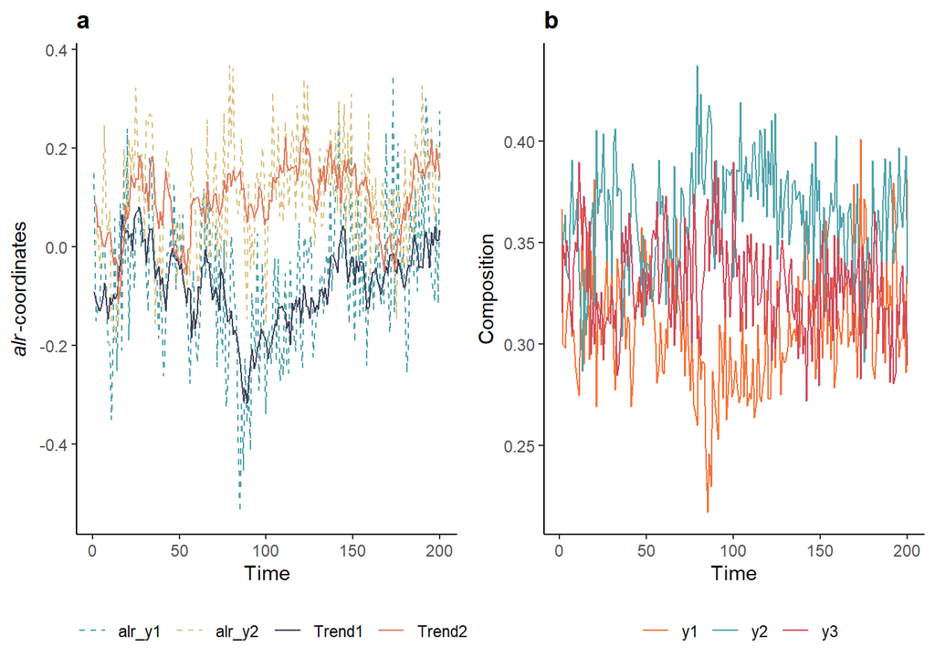

# 4 Data preparation

Prepare data for inference with R-INLA

```r
y <- data[,paste0("y", 1:D)]
data <- alr(y) %>% as.data.frame()

D <- ncol(y)
N <- nrow(y)
names_y <- colnames(y)
names_alry <- colnames(data)
```

## 4.1 Extending the dataset

Extend the dataset of the $alr$-coordinates to fit in the `inla.stack`.

```r
data_ext <- data %>%
  tidyr::pivot_longer(., cols = names_alry,
                      names_to = "alr_names",
                      values_to = "alr_resp") %>%
  .[order(ordered(.$alr_names)),]
data_ext$alr_names <- ordered(data_ext$alr_names)
head(data_ext)
```

| alr_names | alr_resp |
| --- | --- |
| y1 | 0.149750794 |
| y1 | -0.150557150 |
| y1 | -0.128257402 |
| y1 | -0.118043346 |
| y1 | -0.052843428 |
| y1 | -0.008004691 |

## 4.2 Index for the temporal effects

```r
iset <- inla.spde.make.index('i', n.spde = nrow(data),
                             n.repl  = D-1) #Replicating temporal effect
```

## 4.3 Define the part to the shared random effect

```r
# Index for the random effect that is going to give the correlation
id_z <- rep(1:(dim(data_ext)[1]/(D-1)), D-1)

# Index for indicating the alr-coordinate
id_cat <- rep(1:(D-1), rep(N, D-1))
```

## 4.4 Fixed effects

Covariates are included in the model as random effects with big variances. Here we are going to include the intercept.

```r
variables <- c("intercept")
id_names <- paste0("id_", variables)
id_variables <- rep(id_cat, length(variables)) %>%
  matrix(., ncol = length(variables), byrow = FALSE)
colnames(id_variables) <- id_names
```

## 4.5 Response variable in R-INLA

Matrix with dimmension $(N \times (D-1)) \times (D - 1)$ for including the multivariate response in R-INLA.

```r
1:length(names_alry) %>%
  lapply(., function(i){
    data_ext %>%
      dplyr::filter(alr_names == names_alry[i]) -> data_comp_i
    #Response
    y_alr <- matrix(ncol = names_alry %>% length(.), nrow = dim(data_comp_i)[1])
    y_alr[, i] <- data_comp_i$alr_resp
  }) -> alr_resp

1:length(names_alry) %>%
  lapply(., function(i){
    y_aux <- data_ext %>%
      dplyr::select(alr_resp, alr_names) %>%
      dplyr::filter(alr_names == names_alry[i]) %>%
      dplyr::select(alr_resp) %>%
      as.matrix(.)
    aux_vec <- rep(NA, (D-1))
    aux_vec[i] <- 1
    kronecker(aux_vec, y_aux)
  }) -> y_list

y_alr <- do.call(cbind, y_list)
```

## 4.6 INLA stack for estimation

```r
stk_est <- inla.stack(
  data    = list(resp = y_alr),
  A       = list(1, 1),
  effects = list(c(iset),
                 data.frame(id_z,
                            id_variables,
                            intercept = 1)
  ),
  tag     = 'est'
)
```

# 5 Model

The before definition of LND model allows to make estimates with independent Gaussian distributions ($z_d$ to be an independent Gaussian random variable with different mean $\mu-d$ and variances $\sigma^2_d$) and a shared random effect between predictors $u \sim N(0, \gamma)$, defined as:

$$y_1 = z_1 + u, \\
y_2 = z_2 + u \\
... \\
y_{D-1} = z_{D-1} + u.$$

## 5.1 Fitting the model

Have different parameters for fixed effects, and different realizations of the temporal effect for each linear predictor

```r
formula_model <- resp ~ -1 +
  f(id_intercept, intercept,
    model = "iid",
    initial = log(1/1000),
    fixed = TRUE) +
  f(i,
    model = "ar1",
    replicate = i.repl) +
  f(id_z,
    model = "iid",
    constr = TRUE)

model <- inla(
  formula_model,
  family = rep("gaussian", D - 1),
  data = inla.stack.data(stk_est),
  control.compute = list(config = TRUE),
  control.predictor = list(A = inla.stack.A(stk_est),
                           compute = TRUE),
  verbose = FALSE
)
```

## 5.2 Posterior distributions

### 5.2.1 Temporal effect

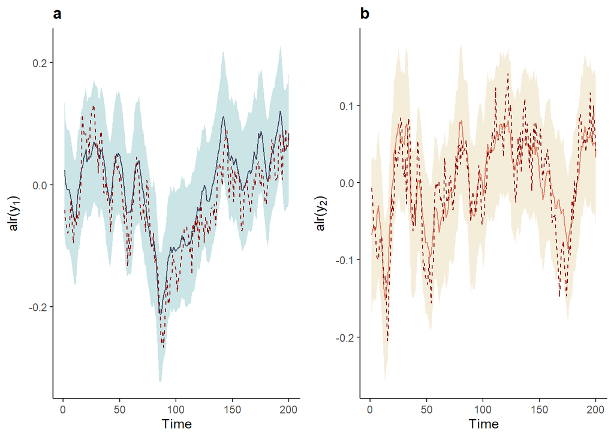

```r
model <- model
temporal_median <- matrix(model$summary.random$i$'0.5quant', byrow = FALSE, ncol = D -1)
temporal_025 <- matrix(model$summary.random$i$'0.025quant', byrow = FALSE, ncol = D -1)
temporal_975 <- matrix(model$summary.random$i$'0.975quant', byrow = FALSE, ncol = D -1)

p1 <- ggplot() +
    geom_ribbon(data = data.frame(x = 1:n, q25 = temporal_025[, 1], q975 = temporal_975[, 1]), aes(x = x, ymin = q25, ymax = q975), fill = "#4FA3AB", alpha = 0.3) +
  geom_line(data = data.frame(x = 1:n, y = temporal_median[, 1]), aes(x = x, y = y), color = "#3d405b", size = 0.5) +
    geom_line(data = data.frame(x = 1:n, y = trend[, 1]), aes(x = x, y = y), color = "red4", size = 0.5, linetype = "dashed") +
    ylab(expression("alr(y"[1]*")")) +
    xlab("Time") +
    ggtitle("a") +
    theme_classic() +
    theme(plot.title = element_text(face = "bold"))

p2 <- ggplot() +
    geom_ribbon(data = data.frame(x = 1:n, q25 = temporal_025[, 2], q975 = temporal_975[, 2]), aes(x = x, ymin = q25, ymax = q975), fill = "#dac484", alpha = 0.3) +
  geom_line(data = data.frame(x = 1:n, y = temporal_median[, 2]), aes(x = x, y = y), color = "#e07a5f", size = 0.5) +
    geom_line(data = data.frame(x = 1:n, y = trend[, 2]), aes(x = x, y = y), color = "red4", size = 0.5, linetype = "dashed") +
    ylab(expression("alr(y"[2]*")")) +
    xlab("Time") +
    ggtitle("b") +
    theme_classic() +
    theme(plot.title = element_text(face = "bold"))

p <- ggpubr::ggarrange(p1, p2)
#ggsave("estimated_temporal_trend_sim.pdf", p, height = 4, width = 7)
print(p)
```

### 5.2.2 Fixed effects

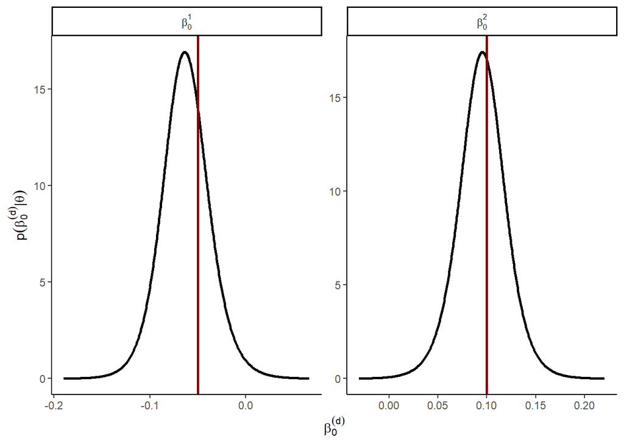

```r
beta0 <- lapply(1:(D-1), function(i) inla.smarginal(model$marginals.random$id_intercept[[i]]))
names(beta0) <- c("1", "2")

beta0_df <- lapply(1:length(beta0),
                   function(i){
                     cbind(data.frame(beta0[[i]]), name1 = names(beta0)[i])
                   })  %>%
  do.call(rbind.data.frame, .)

beta0_real <- data.frame(real = intercept,
                         name1 = c("1", "2"))

p <- ggplot() +
  geom_line(data = beta0_df, aes(x = x, y = y), size = 1) +
  geom_vline(data = beta0_real, aes(xintercept = real), col = "red4", size = 1) +
  theme_classic() +
  theme(legend.position = "bottom") +
  facet_wrap(~ name1, nrow = 1, scales = "free",
               labeller = label_bquote(beta [0] ^ .(name1))) +
  xlab(expression(beta[0]^(d))) +
  ylab(expression(p(beta[0]^(d) *'|'* theta))) +
  theme(legend.title = element_blank())

#ggsave("estimated_intercept_sim.pdf", p, height = 4, width = 7)
print(p)
```

### 5.2.3 Hyperparameters

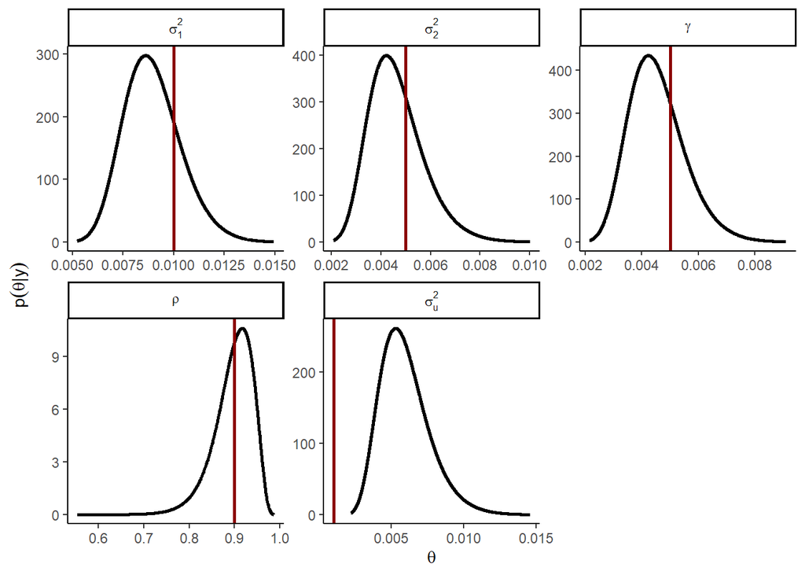

```r
prec <- model$marginals.hyperpar[1:(D-1)] %>%
  c(., list(model$marginals.hyperpar$`Precision for id_z`), list(model$marginals.hyperpar$`Precision for i`))

hyper <- lapply(1:length(prec),
                function(x){
                  inla.smarginal(inla.tmarginal(prec[[x]], fun = function(y)(1/y))) %>%
                    data.frame(.)
                })
names(hyper) <- c(paste0("sigma2.", 1:(D-1)), "gamma", "sigma_u")
hyper <- c(hyper, rho = list(inla.smarginal(model$marginals.hyperpar$`Rho for i`)))

hyper.df <- lapply(1:length(hyper),
                   function(x){
                     cbind(data.frame(hyper[[x]]), name1 = names(hyper)[x])
                   })  %>%
  do.call(rbind.data.frame, .)


hyper.df$name1 <- ordered(hyper.df$name1,
                          levels = c("sigma2.1", "sigma2.2",
                                     "gamma", "rho", "sigma_u"),
                          labels = c("sigma[1]^2", "sigma[2]^2", "gamma", "rho", "sigma[u]^2"))


hyper.real <- data.frame(real = c(sigma2_e, gamma, rho, sigma2_u),
                         name1 = c(paste0("sigma2.", 1:(D-1)),
                                   "gamma", "rho", "sigma_u"))

hyper.real$name1 <- as.factor(hyper.real$name1)
hyper.real$name1 <- ordered(hyper.real$name1,
                            levels = c("sigma2.1", "sigma2.2",
                                       "gamma", "rho", "sigma_u"),
                            labels = c("sigma[1]^2", "sigma[2]^2", "gamma", "rho", "sigma[u]^2"))



p <- ggplot(hyper.df) +
  geom_line(aes(x = x, y = y), size = 1) +
  geom_vline(data = hyper.real, aes(xintercept = real), col = "red4", size = 1) +
  facet_wrap(~ name1, scales = "free",
             labeller = label_parsed) +
  theme_classic() +
  xlab(expression(theta)) +
  ylab(expression(p(theta*'|'*y)))

#ggsave("estimated_hyperparams_sim.pdf", p, height = 4, width = 7)
print(p)
```